# Experimenting with EDA Techniques

Logan Cones

June 1, 2019

# Introduction

We are going to take a look at a couple Kaggle Datasets as a refresher of EDA techniques in R.

```r
setwd('C:\\Users\\Logan Cones\\Desktop\\2019\\R Book\\')
df <- read.csv('cereal.csv')
head(df)
```

```
##                        name mfr type calories protein fat sodium fiber
## 1                 100% Bran   N    C       70       4   1    130  10.0
## 2         100% Natural Bran   Q    C      120       3   5     15   2.0
## 3                  All-Bran   K    C       70       4   1    260   9.0
## 4 All-Bran with Extra Fiber   K    C       50       4   0    140  14.0
## 5            Almond Delight   R    C      110       2   2    200   1.0
## 6   Apple Cinnamon Cheerios   G    C      110       2   2    180   1.5
##   carbo sugars potass vitamins shelf weight cups   rating
## 1   5.0      6    280       25     3      1 0.33 68.40297
## 2   8.0      8    135        0     3      1 1.00 33.98368
## 3   7.0      5    320       25     3      1 0.33 59.42551
## 4   8.0      0    330       25     3      1 0.50 93.70491
## 5  14.0      8     -1       25     3      1 0.75 34.38484
## 6  10.5     10     70       25     1      1 0.75 29.50954
```

# Exploratory Data Analysis

Many different types of metrics to get the middle location or descripitive statistics

- Simple Mean
- Trimmed Mean helps with outliers and is different than the median
- Tried and True Center value or Median

```r
#Simple Mean
mean(df$calories)
```

```
## [1] 106.8831
```

```r
#Trimmed Mean
mean(df$calories, trim=.1)
```

```
## [1] 107.3016
```

```r
#Median
median(df$calories)
```

```
## [1] 110
```

```r
#This is similiar to describe() in python gives you a lot of descriptive statistics
#summary(df)
```

```r
#could also experiment with a weighted mean
library(matrixStats)
library(dplyr)
weighted.mean(df$calories, w = df$protein)
```

```
## [1] 107.0408
```

```r
weightedMedian(df$calories, w = df$protein)
```

```
## [1] 110
```

## Variability

You also want to be concerned with the variability in the data * Variance is the sum of squared deviations from the mean divided by n - 1 * Standard deviation is the square root of the variance * IQR 25th percentile and 75th percentile

```r
sd(df$calories)
```

```
## [1] 19.48412
```

```r
IQR(df$calories)
```

```
## [1] 10
```

```r
#Mean Absolute Deviation from the Median
mad(df$calories)
```

```
## [1] 14.826
```

### Why do we use Degrees of Freedom?

It’s all about wanting to make estimates about a population and not based on a sample Essnetially if you divide by n you will underestimate the true value of the variance and the standard deviation of the population. This is referred to as a biased estimate N-1 results in unbiased estimate.

## Exploring the Distrubutions

Easy Techniques for doing this

- Frequency Table
- Boxplot (my personal fav)
- Density Plot
- Histogram

```r
quantile(df$calories, p=c(.01, .05, .25, .5, .75, .95, .99))
```

```
##    1%    5%   25%   50%   75%   95%   99%
##  50.0  70.0 100.0 110.0 110.0 140.0 152.4
```

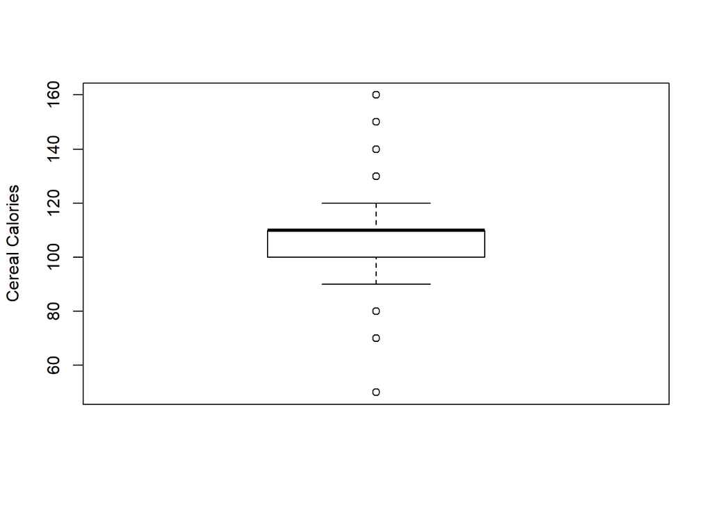

```r
boxplot(df$calories, ylab = "Cereal Calories")
```

Frequency Tables are actually pretty cool

```r
breaks <- seq(from= min(df$calories),
              to = max(df$calories), length = 5)
pop_freq <- cut(df$calories, breaks = breaks, right = TRUE, include.lowest = TRUE)
table(pop_freq)
```

```
## pop_freq
##  [50,77.5] (77.5,105]  (105,132]  (132,160]
##          5         25         41          6
```

Histogram

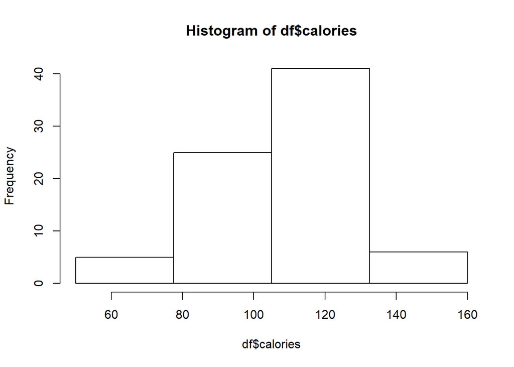

```r
hist(df$calories, breaks = breaks)
```

Density Plots

- Skewness refers to whether the data is skewed to larger or smaller values
- Kurtosis indicates the propensity of the data to have extreme values

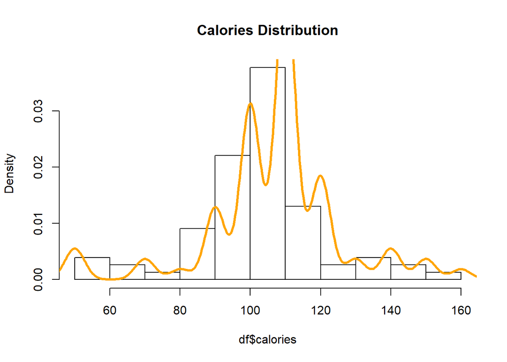

```r
hist(df$calories, freq =  FALSE, main = 'Calories Distribution')
lines(density(df$calories), lwd = 3, col = 'orange')
```

### Exploring Categorical Data

- Use a bar chart which is different than a histogram because a histogram represents values of a single variable on a numeric scale and a bar chart represents different categories of a factor variable

### Correlation

- High correlation means that if high values of X go with high values of Y and low values of x go with low values of Y, it is vice versa then it is negatively corrleated

#### Key Terms

- Correlation Coefficient: A metric that measures the extent to which the numeric vairables are assoicated with one another 1 or -1 is perfect and often a problem in modeling ** If relationship not linear this is pretty useless
- Correlation Matrix: A table where the variables are shown on both rows and columns and the values are the correlations between the variables. Super super helpful techniques if limited features
- Scatterplot: A plot in which the x-axis is the value of one variable and the y-axis is the value of another

#### Correlation in Action

Make a new dataframe of all numeric variables and we what the correlations are

Somewhat surprising more calories is negatively correlated with higher ratings! Must have surveys some mature adults :)

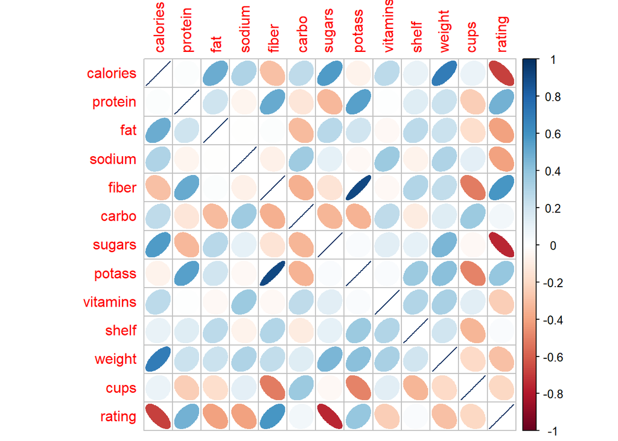

```r
library(corrplot)
library(dplyr)
nums <-  select_if(df, is.numeric)
corrplot(cor(nums), method = 'ellipse')
```

The above graph is based on Pearson’s Correlation which is based purely on value and is not robust to outliers. Other Correlations such as Spearman’s Rho and Kendall’s Tau use Rank of the data. This could be useful in certain situtations.

### Scatterplot

Let’s take another look at the Rating and Carolies combo

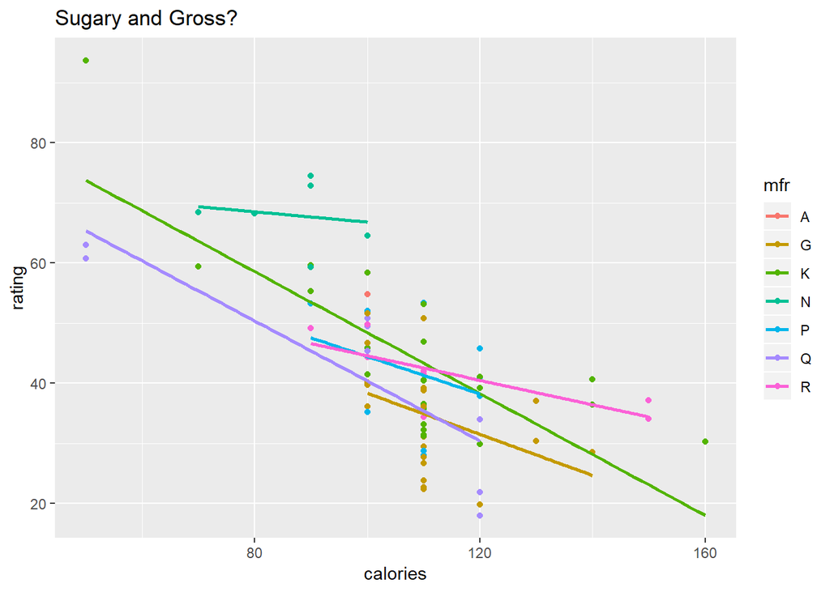

```r
library(ggplot2)
ggplot(data = df, aes(x = calories, y = rating, color=mfr), xlab = 'Calories', ylab = 'Rating') + ggtitle('Sugary and Gross?') + geom_point() + geom_smooth(method=lm, se = FALSE)
```

## Exploring Two or More Variables

Key Terms

- Contingency Tables: A tally of counts between two or more categorical variables
- Hexagonal Binning: A plot of two numeric tables with records binned into hexagons
- Contour Plots: A plot showing the density of two numeric variables like topographical mapping
- Violin Plots Similar to a boxplor but showing the density estimate. These are beautiful in the python package seaborn.

I’m going to load in a new dataset to do these tests with for the Cereal data is too small.

## Diamond Dataset

I recently got engaged to my now fiance so we will take a look at the diamond dataset to learn more about these techniques. This was pulled from everyone’s favorite site Kaggle

```r
df2 <- read.csv('diamonds.csv')
head(df2)
```

```
##   X carat       cut color clarity depth table price    x    y    z
## 1 1  0.23     Ideal     E     SI2  61.5    55   326 3.95 3.98 2.43
## 2 2  0.21   Premium     E     SI1  59.8    61   326 3.89 3.84 2.31
## 3 3  0.23      Good     E     VS1  56.9    65   327 4.05 4.07 2.31
## 4 4  0.29   Premium     I     VS2  62.4    58   334 4.20 4.23 2.63
## 5 5  0.31      Good     J     SI2  63.3    58   335 4.34 4.35 2.75
## 6 6  0.24 Very Good     J    VVS2  62.8    57   336 3.94 3.96 2.48
```

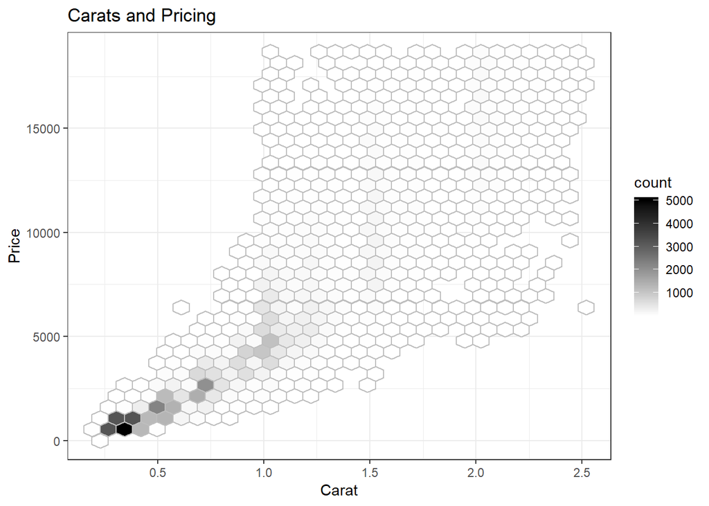

```r
#let's get rid of the crazy people that have more than 2.5 Carats cause that's insane
df2 <- subset(df2, carat < 2.5)

ggplot(df2, (aes(x=carat, y = price)))+ ggtitle('Carats and Pricing' ) + stat_bin_hex(colour= 'gray') + theme_bw() + scale_fill_gradient(low='white', high = 'black') + labs(x="Carat", y = 'Price')
```

Not sure this next technique is going to be super useful here but it’s an interesting approach to exploration as is. Take two categorical variables and make a contingency table of them

```r
library(descr)
CrossTable(df2$clarity, df2$cut, prop.c = FALSE, prop.chisq=FALSE, prop.t = FALSE)
```

```
##    Cell Contents
## |-------------------------|
## |                       N |
## |           N / Row Total |
## |-------------------------|
##
## ==================================================================
##                df2$cut
## df2$clarity     Fair    Good   Ideal   Premium   Very Good   Total
## ------------------------------------------------------------------
## I1               196      94     141       193          80     704
##                0.278   0.134   0.200     0.274       0.114   0.013
## ------------------------------------------------------------------
## IF                 9      71    1212       230         268    1790
##                0.005   0.040   0.677     0.128       0.150   0.033
## ------------------------------------------------------------------
## SI1              408    1560    4278      3570        3238   13054
##                0.031   0.120   0.328     0.273       0.248   0.243
## ------------------------------------------------------------------
## SI2              452    1066    2582      2919        2086    9105
##                0.050   0.117   0.284     0.321       0.229   0.169
## ------------------------------------------------------------------
## VS1              170     648    3588      1988        1775    8169
##                0.021   0.079   0.439     0.243       0.217   0.152
## ------------------------------------------------------------------
## VS2              261     977    5070      3355        2591   12254
##                0.021   0.080   0.414     0.274       0.211   0.228
## ------------------------------------------------------------------
## VVS1              17     186    2047       616         789    3655
##                0.005   0.051   0.560     0.169       0.216   0.068
## ------------------------------------------------------------------
## VVS2              69     286    2606       870        1235    5066
##                0.014   0.056   0.514     0.172       0.244   0.094
## ------------------------------------------------------------------
## Total           1582    4888   21524     13741       12062   53797
## ==================================================================
```

Then of course my favorite and the one that seems most useful in my current role is box plots of cateogrical variables. Let’s make some Violin plots with clarity and price. Even though I just bought a ring I didn’t dive this deep into the process. WISH I DID THIS BEFORE HAND! Doesn’t really seem like splitting it up by cut moves the needle as much as I would have thought.

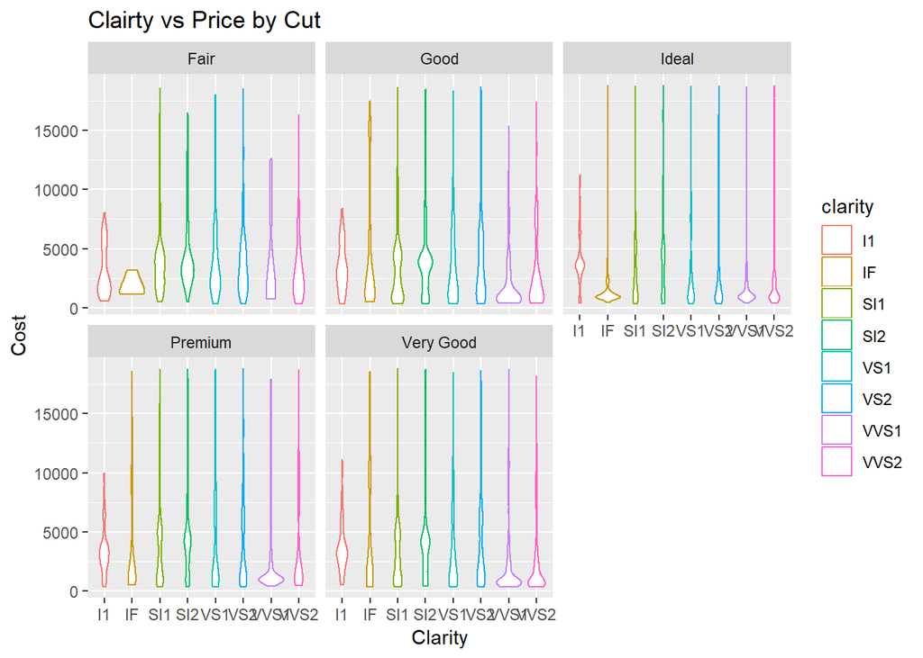

```r
ggplot(df2, aes(clarity, price, color= clarity)) + geom_violin() + labs(x = 'Clarity', y = 'Cost') + facet_wrap('cut') + ggtitle('Clairty vs Price by Cut')
```